# Cole Striler & Jenny Sokolsky

- Home
- Project Code
- Sources

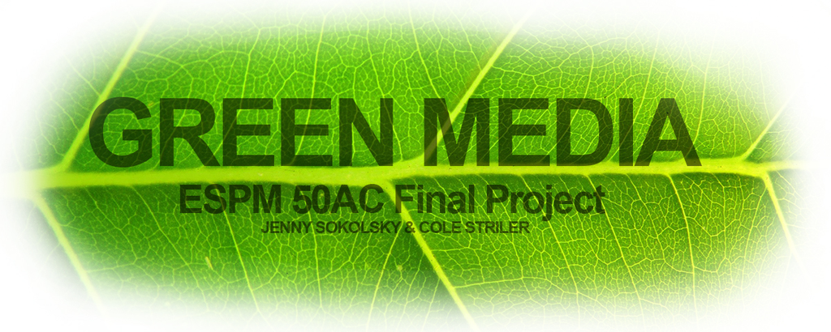

```python
Image("cover.jpg")
```

# 1. Choosing Our Data

Beginning our project, we knew we wanted to work with an informative dataset that would lead us to interesting discoveries. With a deep search into many database sites, including data.gov, Kaggle, and enviroscreen.org, we chose a dataset that consists of every Huffington Post article from the years 2012-2018. We thought this dataset encompassed a variety of features that we could play with. We were inspired by Kurt's lectures about media and culture, and wanted to create a final project that showcased the connection between the two. This is why we focused our efforts on the media's effects on our society, especially looking at the environmental perspective.

The first thing we looked at were the different categories of the dataset. We created an initial bar plot showing the number of articles in each category. As you can see, most of the articles were about `politics`, amounting to an article count of over 30,000. The least number of articles fell under the `education` category. The two categories that seemed the most relevant to this class were `environment` and `green`, so we ended up only looking within those. There are 1323 `environment` articles and 2622 `green` articles

This dataset is from Kaggle and consists of Huffington Post articles from 2012-2018.

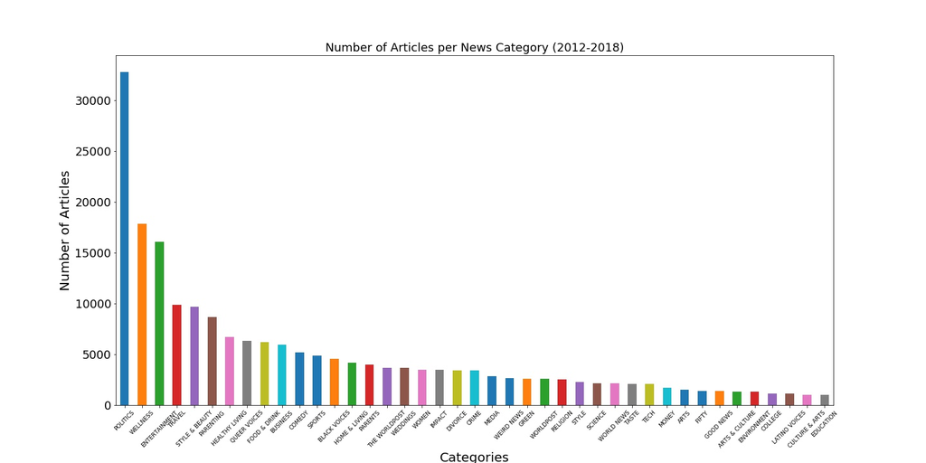

```python
from IPython.display import Image
Image("img/categories.jpg")
```

When we first narrowed our data down into just the `green` and `environment` categories, we noticed something interesting. Before 2014, there were only `environment` articles and after 2014 there were only `green` articles. After looking into this, we believe that the Huffington Post used the two category names to represent the same topic. Therefore, we felt that combining the two was appropriate.

The shift from "environment" to "green" topics could be attributed to the increase in the number of [going green initiatives](https://gogreeninitiative.org/) that have been spreading and gaining more and more awareness as time goes on. A lot of people disassociate themselves with the word "environment" since its implication can be triggering, but [studies show](https://www.verywellmind.com/color-psychology-green-2795817) the majority of people respond positively to the term "green".

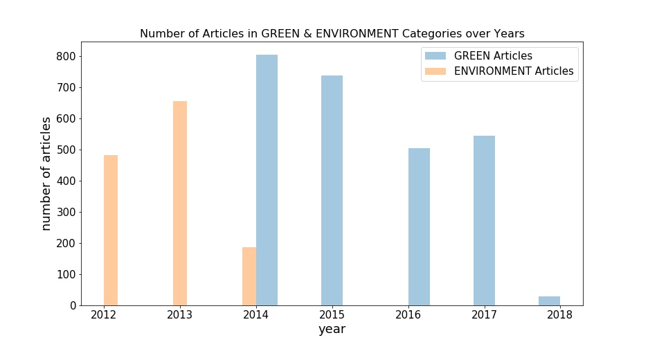

```python
Image("img/env_vs_green.jpg")
```

# 2. Polarity in Headlines

Next, we worked with the headlines in our dataset in order to come up with analytical predicitons. It turns out that we can use the words in news headlines to calculate a measure of the sentiment of the headline. For example, the sentence "I love America!" has positive sentiment, whereas the sentence "I hate taxes!" has a negative sentiment. In addition, some words have stronger positive / negative sentiment than others: "I love America." is more positive than "I like America."

We used the VADER (Valence Aware Dictionary and sEntiment Reasoner) lexicon to analyze the sentiment of the news headlines. VADER is a lexicon and rule-based sentiment analysis tool that is specifically attuned to sentiments expressed in social & news media which is great for our usage.

Polarity is defined as:

Polarity > 0 Means **Positive** News Headlines

Polarity < 0 Means **Negative** News Headlines

Polarity = 0 Means **Neutral** News Headlines

### What is the Huffington Post?

Before we really start exploring, it's important to address any biases that might be present in the dataset. Almost every news source has some sort of political bias, so we wanted to see if we can guess the political bias of the Huffington Post only using our dataset. Here is how we did that:

We first took every news headline and gave it a polarity rating

We then split the data into two categories: headlines that contain "trump", and headlines that contain "obama"

We then plotted each distribution and calculated their corresponding means

The result of our findings is below:

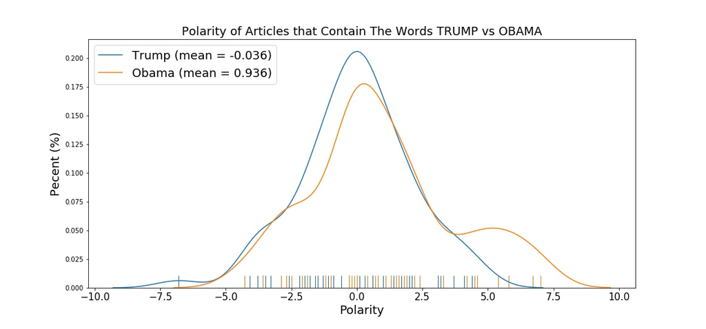

```python
Image("img/political_bias.jpg")
```

As you can see, articles that contain the word "OBAMA" have an average polarity of 0.936 (more positive) and articles that contain the word "TRUMP" have an average polarity of -0.036 (slightly more negative). This means that, on average, articles about President Obama from the Huffington Post are more positive than they are about Trump. Therefore, **we predict that the Huffington Post is a liberal news source**. It was interesting to see how data can show whether a new source is biased to one side. And we can check our results with a quick google search.

[figure not shown]

```python
Image("img/google.png")
```

Next, we look at change in news polarity over time. As you can see from the plot below, news polarity peaked in 2013 and then began dropping significantly. One thing that stands out is the severe drop in polarity in 2017. We thought this seemed very unusual, so we decided to investigate.

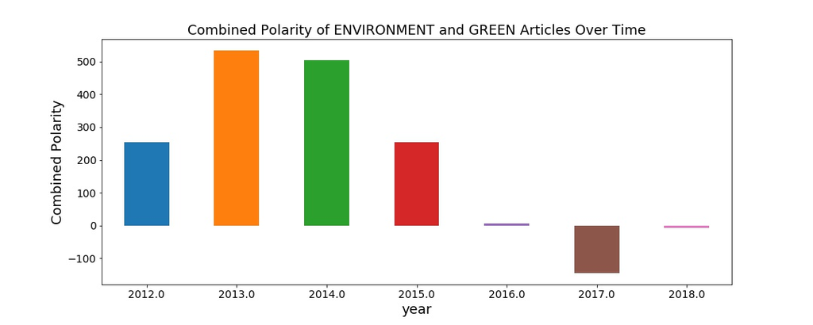

```python
Image("img/polarity_years.jpg")
```

We thought the first thing we should do is look at the most common words contained in articles in each of the two years. This could give us some insight into the major events that were talked about. First, we look at the most common words in 2013 headlines.

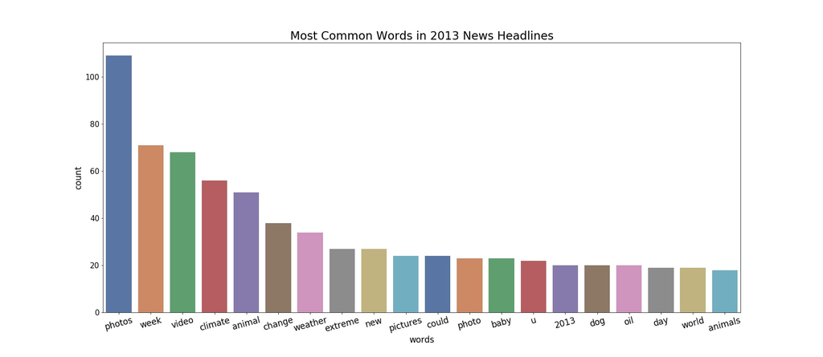

```python
Image("img/2013_headlines.jpg")
```

The graph above shows a very significant portion of the most common words focused around photos and videos of the week, with "climate" and "animal" following in number of counts. It seems like the most common words are ones that evoke positive emotions, like "dog", "baby", and "animals". But, there are some relatively negative words in there, like "extreme", "climate", and "oil". Nothing significant stands out here. We then look at the most common words in 2017:

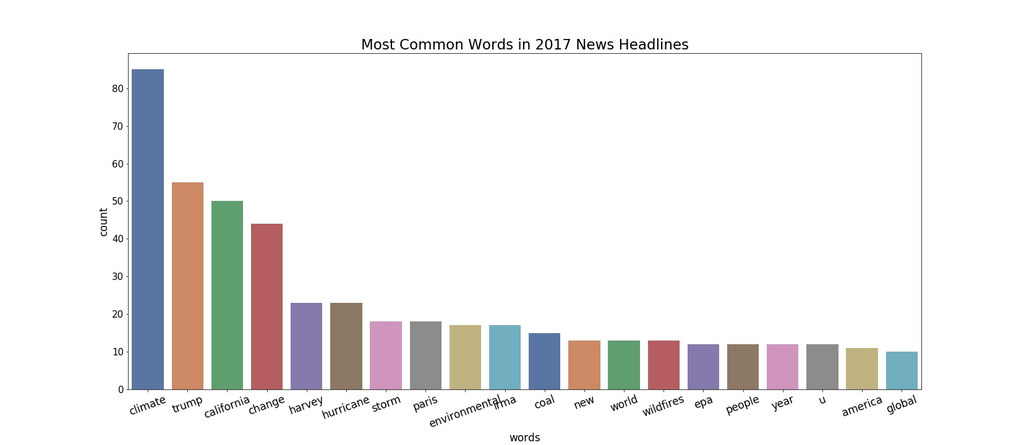

```python
Image("img/2017_headlines.jpg")
```

Unlike the top words in 2013 articles, the top 20 words in this plot have much more negative connotations associated with them. For example, we see that the word "climate" rose to top, which we can assums is because of the ongoing debates about climate change. In addition, President Trump's first day of office was January 1, 2017 so in the media "trump" was a very controversial topic, especially coming from a left leaning news source. A few more words that stood out were "hurricane", "harvey", and "irma". After a few web searches, we found that these storms also occured in 2017 -- not surpising. Another interesting factor that came out as a common word is the presence of the EPA, the Environmental Protection Agency within this dataset. We guess this is because of the high mentions of wildfires and hurricanes.

Next, we looked at when the actual mentions of "obama" and "trump" occured. As you can see, the number of articles that mention President Obama is pretty evenly spread out, whereas the articles that talk about President Trump seems to be clustered around the time he took office.

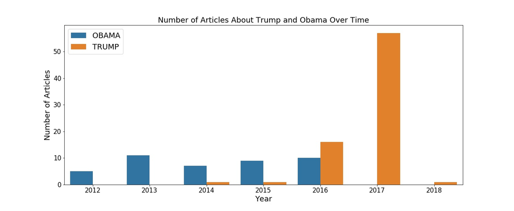

```python
Image("img/presidents_over_time.jpg")
```

The final thing we looked at is the change in polarity of articles written about President Trump over time.

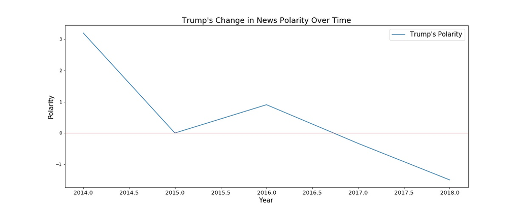

```python
Image("img/trump.jpg")
```

Before Trump took office, articles about him were not that bad. Once he was elected in 2016, however, articles written about him began to drop in polarity. Kind of interesting

# 3. Conclusion

Doing this project, we faced several challenges. The first was with the dataset itself. Days after committing to this topic and data, we realized that there wasn't much to work with. The nature of the data set was limited and we realized it would be hard to make any break through discoveries with it. We had two options: come up with an entire new project, or work with what we got. We chose the latter.

It then became a matter of "How creative can you get?" We spent many hours trying to figure out different ways to explore this dataset and eventually realized that politics and news polarity had the most interesting data to look at. Our goal was to scrape as much information from the data as possible, and I think we did just that.

In the end, we have no major findings or predictions to report, but we do have a few comments.

From what we saw, the polarity in the media is rapidly declining and our content is becoming much more negative. Looking beyond just our project, we believe this is a major issue in many news sources other than the Huffington Post as well. It's important to be aware of these kinds of things because most people gather most of their understanding about the world from the news. Other things that could be looked at beyond the scope of this project is the link between news polarity and other major events that happen in the world -- such as happiness scores, mass shootings, etc. We had a great time doing this project and hope the reader enjoyed our findings.